# *ropls*: PCA, PLS(-DA) and OPLS(-DA) for multivariate analysis and feature selection of omics data

Etienne A. Thevenot

25 June 2018

#### Package

ropls 1.13.2

# 1 The *ropls* package

The [ropls](http://bioconductor.org/packages/release/bioc/html/ropls.html) R package implements the **PCA**, **PLS(-DA)** and **OPLS(-DA)** approaches with the original, **NIPALS**-based, versions of the algorithms (Wold, Sjostrom, and Eriksson 2001, J. Trygg and Wold (2002)). It includes the **R2** and **Q2** quality metrics (Eriksson et al. 2001, Tenenhaus (1998)), the permutation **diagnostics** (Szymanska et al. 2012), the computation of the **VIP** values (Wold, Sjostrom, and Eriksson 2001), the score and orthogonal distances to detect **outliers** (Hubert, Rousseeuw, and Vanden Branden 2005), as well as many **graphics** (scores, loadings, predictions, diagnostics, outliers, etc).

The functionalities from [ropls](http://bioconductor.org/packages/release/bioc/html/ropls.html) can also be accessed via a graphical user interface in the **Multivariate** module from the [Workflow4Metabolomics.org](http://workflow4metabolomics.org) online resource for computational metabolomics, which provides a user-friendly, **Galaxy**-based environment for data pre-processing, statistical analysis, and annotation (Giacomoni et al. 2015).

# 2 Context

## 2.1 Orthogonal Partial Least-Squares

**Partial Least-Squares (PLS)**, which is a latent variable regression method based on covariance between the predictors and the response, has been shown to efficiently handle datasets with multi-collinear predictors, as in the case of spectrometry measurements (Wold, Sjostrom, and Eriksson 2001). More recently, J. Trygg and Wold (2002) introduced the **Orthogonal Partial Least-Squares (OPLS)** algorithm to model separately the variations of the predictors correlated and orthogonal to the response.

OPLS has a similar predictive capacity compared to PLS and improves the **interpretation** of the predictive components and of the systematic variation (Pinto, Trygg, and Gottfries 2012). In particular, OPLS modeling of single responses only requires one predictive component.

**Diagnostics** such as the **Q2Y** metrics and permutation testing are of high importance to **avoid overfitting** and assess the statistical significance of the model. The **Variable Importance in Projection (VIP)**, which reflects both the loading weights for each component and the variability of the response explained by this component (Pinto, Trygg, and Gottfries 2012; Mehmood et al. 2012), can be used for feature selection (J. Trygg and Wold 2002; Pinto, Trygg, and Gottfries 2012).

## 2.2 OPLS software

OPLS is available in the **SIMCA-P** commercial software (Umetrics, Umea, Sweden; Eriksson et al. (2001)). In addition, the kernel-based version of OPLS (M. Bylesjo et al. 2008) is available in the open-source R statistical environment (R Development Core Team 2008), and a single implementation of the linear algorithm in R has been described recently (Gaude et al. 2013).

# 3 The *sacurine* metabolomics dataset

## 3.1 Study objective

The objective was to study the influence of **age**, **body mass index (bmi)**, and **gender** on metabolite concentrations in **urine**, by analysing 183 samples from a **cohort** of adults with liquid chromatography coupled to high-resolution mass spectrometry (**LC-HRMS**; Thevenot et al. (2015)).

## 3.2 Pre-processing and annotation

Urine samples were analyzed by using an LTQ Orbitrap in the negative ionization mode. A total of **109 metabolites** were identified or annotated at the MSI level 1 or 2. After retention time alignment with XCMS, peaks were integrated with Quan Browser. Signal drift and batch effect were corrected, and each urine profile was normalized to the osmolality of the sample. Finally, the data were log10 transformed (Thevenot et al. 2015).

## 3.3 Covariates

The volunteers’ **age**, **body mass index (bmi)**, and **gender** were recorded.

# 4 Hands-on

## 4.1 Loading

We first load the [ropls](http://bioconductor.org/packages/release/bioc/html/ropls.html) package:

```r
library(ropls)
```

We then load the **sacurine** dataset which contains:

1. The **dataMatrix** matrix of numeric type containing the intensity profiles (log10 transformed),
2. The **sampleMetadata** data frame containg sample metadata,
3. The **variableMetadata** data frame containg variable metadata

```r
data(sacurine)
names(sacurine)
```

```
## [1] "dataMatrix"       "sampleMetadata"   "variableMetadata"
```

We attach **sacurine** to the search path and display a summary of the content of the **dataMatrix**, **sampleMetadata** and **variableMetadata** with the `strF` *F*unction of the [ropls](http://bioconductor.org/packages/release/bioc/html/ropls.html) package (see also `str`):

```r
attach(sacurine)
```

```r
strF(dataMatrix)
```

```
##        dim  class    mode typeof   size NAs  min mean median max
##  183 x 109 matrix numeric double 0.2 Mb   0 -0.3  4.2    4.3   6
##        (2-methoxyethoxy)propanoic acid isomer (gamma)Glu-Leu/Ile ...
## HU_011                            3.019766011        3.888479324 ...
## HU_014                             3.81433889        4.277148905 ...
## ...                                       ...                ... ...
## HU_208                            3.748127215        4.523763202 ...
## HU_209                            4.208859398        4.675880567 ...
##        Valerylglycine isomer 2  Xanthosine
## HU_011             3.889078716 4.075879575
## HU_014             4.181765852 4.195761901
## ...                        ...         ...
## HU_208             4.634338821 4.487781609
## HU_209              4.47194762 4.222953354
```

```r
strF(sampleMetadata)
```

```
##      age     bmi gender
##  numeric numeric factor
##  nRow nCol size NAs
##   183    3 0 Mb   0
##         age   bmi gender
## HU_011   29 19.75      M
## HU_014   59 22.64      F
## ...     ...   ...    ...
## HU_208   27 18.61      F
## HU_209 17.5 21.48      F
```

```r
strF(variableMetadata)
```

```
##  msiLevel      hmdb chemicalClass
##   numeric character     character
##  nRow nCol size NAs
##   109    3 0 Mb   0
##                                        msiLevel      hmdb chemicalClass
## (2-methoxyethoxy)propanoic acid isomer        2                  Organi
## (gamma)Glu-Leu/Ile                            2                  AA-pep
## ...                                         ...       ...           ...
## Valerylglycine isomer 2                       2           AA-pep:AcyGly
## Xanthosine                                    1 HMDB00299        Nucleo
```

## 4.2 Principal Component Analysis (PCA)

We perform a **PCA** on the **dataMatrix** matrix (samples as rows, variables as columns), with the `opls` method:

```r
sacurine.pca <- opls(dataMatrix)
```

A **summary** of the model (8 components were selected) is printed:

```
## PCA
## 183 samples x 109 variables
## standard scaling of predictors
##       R2X(cum) pre ort
## Total    0.501   8   0
```

In addition the default **summary** figure is displayed:

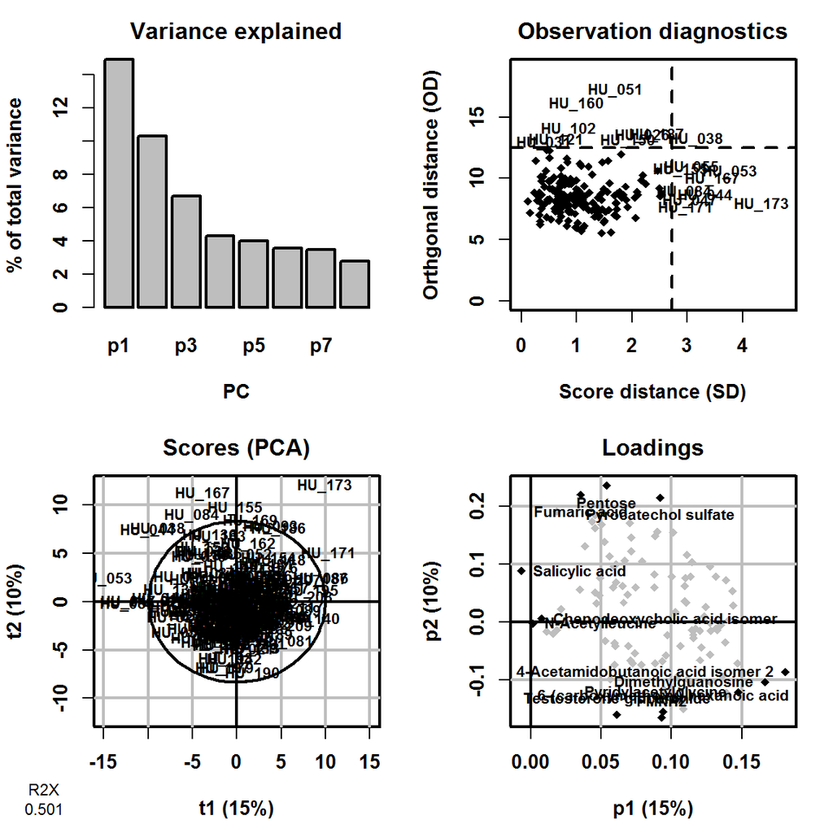

**Figure 1: PCA summary plot.** **Top left** `overview`: the **scree** plot (i.e., inertia barplot) suggests that 3 components may be sufficient to capture most of the inertia; **Top right** `outlier`: this graphics shows the distances within and orthogonal to the projection plane (Hubert, Rousseeuw, and Vanden Branden 2005): the name of the samples with a high value for at least one of the distances are indicated; **Bottom left** `x-score`: the variance along each axis equals the variance captured by each component: it therefore depends on the total variance of the dataMatrix *X* and of the percentage of this variance captured by the component (indicated in the labels); it decreases when going from one component to a component with higher indice; **Bottom right** `x-loading`: the 3 variables with most extreme values (positive and negative) for each loading are black colored and labeled.

Note:

1. Since **dataMatrix** does not contain missing value, the singular value decomposition was used by default; NIPALS can be selected with the `algoC` argument specifying the *algo*rithm (*C*haracter),
2. The `predI = NA` default number of *pred*ictive components (*I*nteger) for PCA means that components (up to 10) will be computed until the cumulative variance exceeds 50%. If the 50% have not been reached at the 10th component, a warning message will be issued (you can still compute the following components by specifying the `predI` value).

Let us see if we notice any partition according to gender, by labeling/coloring the samples according to *gender* (`parAsColFcVn`) and drawing the Mahalanobis ellipses for the male and female subgroups (`parEllipseL`).

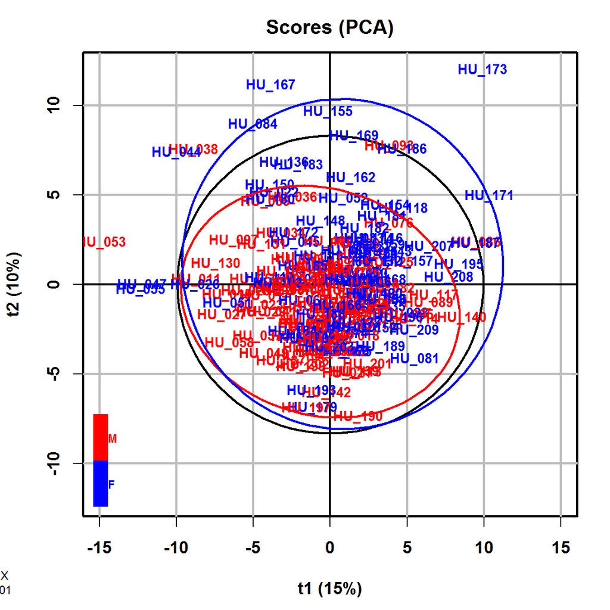

```r
genderFc <- sampleMetadata[, "gender"]
plot(sacurine.pca, typeVc = "x-score",
parAsColFcVn = genderFc, parEllipsesL = TRUE)
```

**Figure 2: PCA score plot colored according to gender.**

Note:

1. The plotting *par*ameter to be used *As* *Col*ors (*F*actor of *c*haracter type or *V*ector of *n*umeric type) has a length equal to the number of rows of the **dataMatrix** (ie of samples) and that this qualitative or quantitative variable is converted into colors (by using an internal palette or color scale, respectively). We could have visualized the *age* of the individuals by specifying `parAsColFcVn = sampleMetadata[, "age"]`.
2. The displayed components can be specified with `parCompVi` (plotting *par*ameter specifying the *Comp*onents: *V*ector of 2 *i*ntegers)

## 4.3 Partial least-squares: PLS and PLS-DA

For **PLS (and OPLS)**, the **Y** response(s) must be provided to the `opls` method. **Y** can be either a numeric vector (respectively matrix) for single (respectively multiple) **(O)PLS regression**, or a character factor for **(O)PLS-DA classification** as in the following example with the *gender* qualitative response:

```r
sacurine.plsda <- opls(dataMatrix, genderFc)
```

```
## PLS-DA
## 183 samples x 109 variables and 1 response
## standard scaling of predictors and response(s)
##       R2X(cum) R2Y(cum) Q2(cum) RMSEE pre ort pR2Y  pQ2
## Total    0.275     0.73   0.584 0.262   3   0 0.05 0.05
```

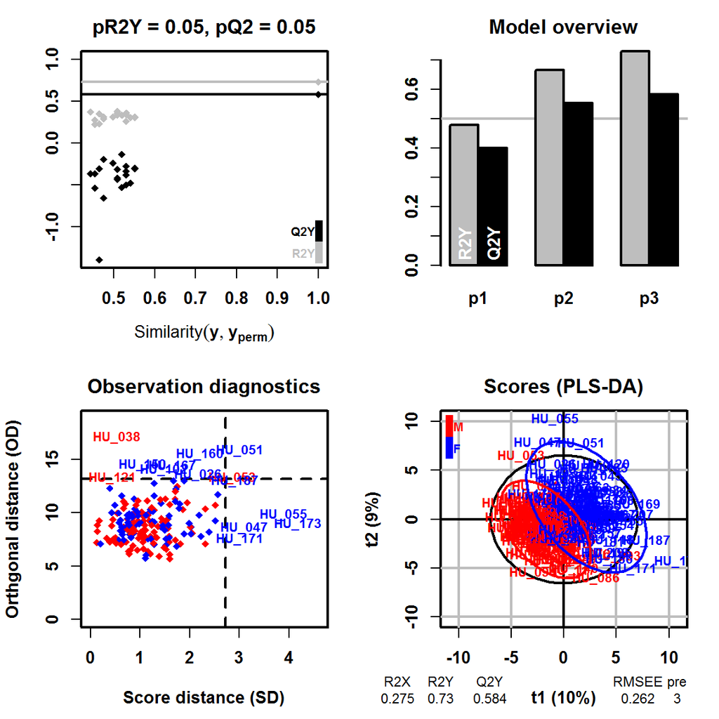

Note:

1. When set to NA (as in the default), **the number of components** `predI` is determined automatically as follows (Eriksson et al. 2001): A new component *h* is added to the model if:
- $R2Y_h \geq 0.01$, i.e., the percentage of **Y** dispersion (i.e., sum of squares) explained by component *h* is more than 1 percent, and
- $Q2Y_h=1-PRESS_h/RSS_{h-1} \geq 0$ for PLS (or 5% when the number of samples is less than 100) or 1% for OPLS: $Q2Y_h \geq 0$ means that the predicted residual sum of squares ($PRESS_h$) of the model including the new component *h* estimated by 7-fold cross-validation is less than the residual sum of squares ($RSS_{h-1}$) of the model with the previous components only (with $RSS_0$ being the sum of squared **Y** values).
2. The **predictive performance** of the full model is assessed by the cumulative **Q2Y** metric: $Q2Y=1-\prod\limits_{h=1}^r (1-Q2Y_h)$. We have $Q2Y \in [0,1]$, and the higher the **Q2Y**, the better the performance. Models trained on datasets with a larger number of features compared with the number of samples can be prone to **overfitting**: in that case, high **Q2Y** values are obtained by chance only. To estimate the significance of **Q2Y** (and **R2Y**) for single response models, permutation testing (Szymanska et al. 2012) can be used: models are built after random permutation of the **Y** values, and $Q2Y_{perm}$ are computed. The *p*-value is equal to the proportion of $Q2Y_{perm}$ above $Q2Y$ (the **default number of permutations is 20** as a compromise between quality control and computation speed; it can be increased with the `permI` parameter, e.g. to 1,000, to assess if the model is significant at the 0.05 level),
3. The **NIPALS** algorithm is used for PLS (and OPLS); *dataMatrix* matrices with (a moderate amount of) missing values can thus be analysed.

We see that our model with 3 predictive (*pre*) components has significant and quite high R2Y and Q2Y values.

## 4.4 Orthogonal partial least squares: OPLS and OPLS-DA

To perform **OPLS(-DA)**, we set `orthoI` (number of components which are *ortho*gonal; *I*nteger) to either a specific number of orthogonal components, or to NA. Let us build an OPLS-DA model of the *gender* response.

```r
sacurine.oplsda <- opls(dataMatrix, genderFc,
predI = 1, orthoI = NA)
```

```
## OPLS-DA
## 183 samples x 109 variables and 1 response
## standard scaling of predictors and response(s)
##       R2X(cum) R2Y(cum) Q2(cum) RMSEE pre ort pR2Y  pQ2
## Total    0.275     0.73   0.602 0.262   1   2 0.05 0.05
```

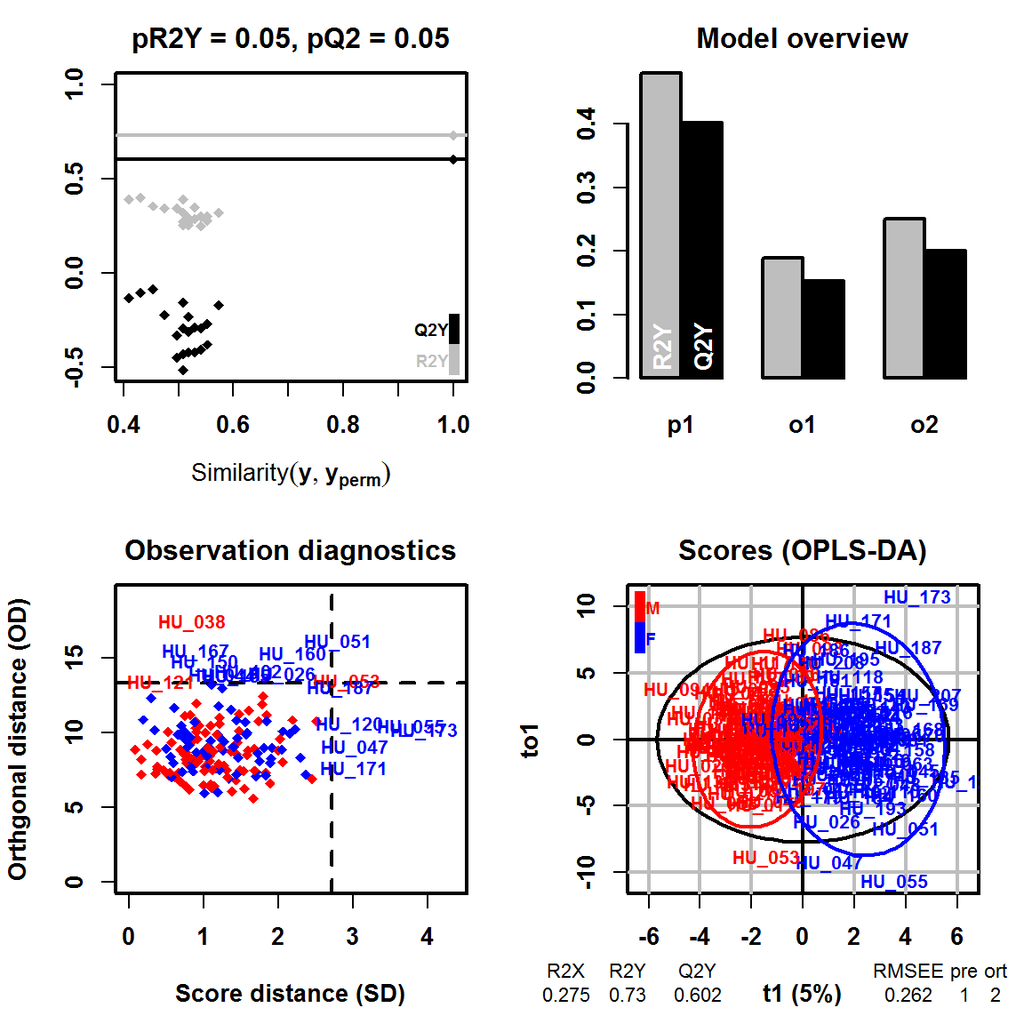

**Figure 4: OPLS-DA model of the gender response.**

Note:

1. For OPLS modeling of a single response, the number of predictive component is 1,
2. In the (`x-score` plot), the predictive component is displayed as abscissa and the (selected; default = 1) orthogonal component as ordinate.

Let us assess the **predictive performance** of our model. We first train the model on a subset of the samples (here we use the `odd` subset value which splits the data set into two halves with similar proportions of samples for each class; alternatively, we could have used a specific subset of indices for training):

```r
sacurine.oplsda <- opls(dataMatrix, genderFc, predI = 1, orthoI = NA,
subset = "odd")
```

```
## OPLS-DA
## 92 samples x 109 variables and 1 response
## standard scaling of predictors and response(s)
##       R2X(cum) R2Y(cum) Q2(cum) RMSEE RMSEP pre ort
## Total     0.26    0.825   0.608 0.213 0.341   1   2
```

We first check the predictions on the **training** subset:

```r
trainVi <- getSubsetVi(sacurine.oplsda)
table(genderFc[trainVi], fitted(sacurine.oplsda))
```

```
##
##      M  F
##   M 50  0
##   F  0 42
```

We then compute the performances on the **test** subset:

```r
table(genderFc[-trainVi],
      predict(sacurine.oplsda, dataMatrix[-trainVi, ]))
```

```
##
##      M  F
##   M 43  7
##   F  7 34
```

## 4.5 Comments

### 4.5.1 Overfitting

**Overfitting** (i.e., building a model with good performances on the training set but poor performances on a new test set) is a major caveat of machine learning techniques applied to data sets with more variables than samples. A simple simulation of a random **X** data set and a **y** response shows that perfect PLS-DA classification can be achieved as soon as the number of variables exceeds the number of samples, as detailed in the example below, adapted from Wehrens (2011):

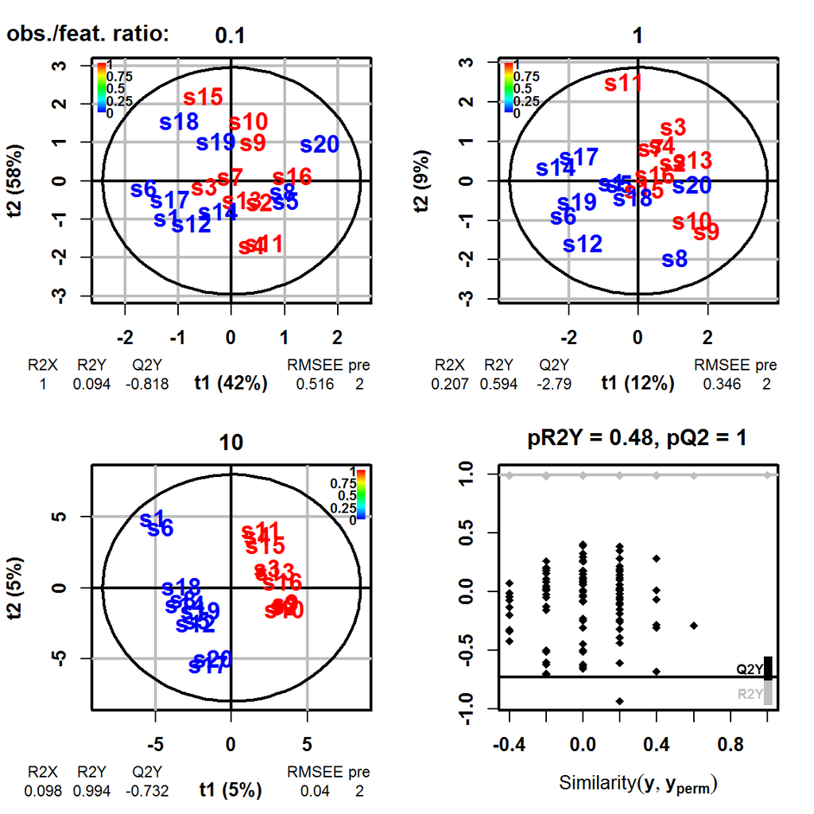

**Figure 5: Risk of PLS overfitting.** In the simulation above, a **random matrix X** of 20 observations x 200 features was generated by sampling from the uniform distribution $U(0, 1)$. A **random y** response was obtained by sampling (without replacement) from a vector of 10 zeros and 10 ones. **Top left**, **top right**, and **bottom left**: the X-**score plots** of the PLS modeling of **y** by the (sub)matrix of **X** restricted to the first 2, 20, or 200 features, are displayed (i.e., the observation/feature ratios are 0.1, 1, and 10, respectively). Despite the good separation obtained on the bottom left score plot, we see that the **Q2Y** estimation of predictive performance is low (negative); **Bottom right**: a significant proportion of the models (in fact here all models) trained after random permutations of the labels have a higher **Q2Y** value than the model trained with the true labels, confirming that PLS cannot specifically model the **y** response with the **X** predictors, as expected.

This simple simulation illustrates that PLS overfit can occur, in particular when the number of features exceeds the number of observations. **It is therefore essential to check that the $Q2Y$ value of the model is significant by random permutation of the labels**.

### 4.5.2 VIP from OPLS models

The classical **VIP** metric is not useful for OPLS modeling of a single response since (Galindo-Prieto, Eriksson, and Trygg 2014, Thevenot et al. (2015)): 1. **VIP** values remain identical whatever the number of orthogonal components selected, 2. **VIP** values are univariate (i.e., they do not provide information about interactions between variables). In fact, when features are standardized, we can demonstrate a mathematical relationship between VIP and *p*-values from a Pearson correlation test (Thevenot et al. 2015), as illustrated by the figure below:

```
## OPLS
## 183 samples x 109 variables and 1 response
## standard scaling of predictors and response(s)
##       R2X(cum) R2Y(cum) Q2(cum) RMSEE pre ort pR2Y  pQ2
## Total    0.212    0.476    0.31  7.53   1   1 0.05 0.05
```

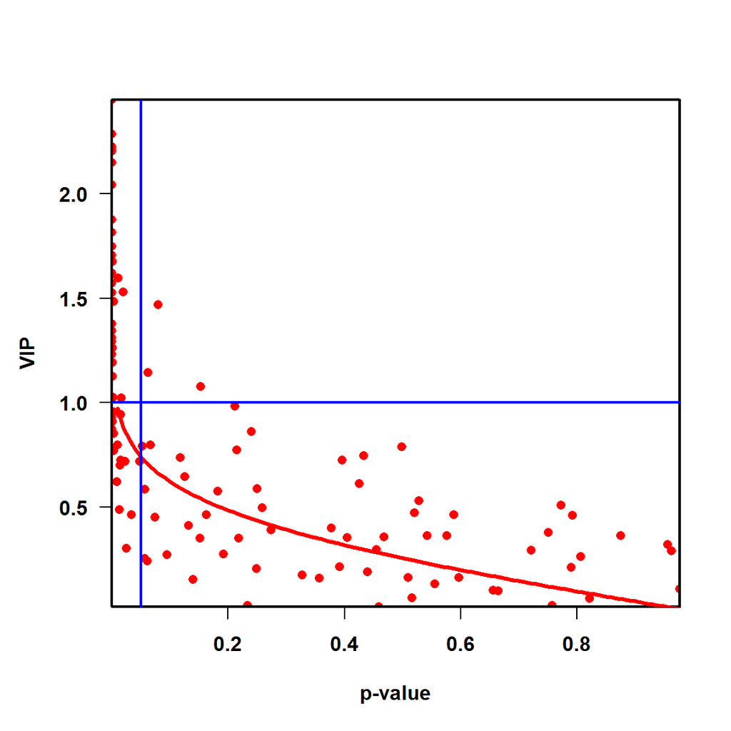

**Figure 6: Relationship between VIP from one-predictive PLS or OPLS models with standardized variables, and p-values from Pearson correlation test.** The $(p_j, VIP_j)$ pairs corresponding respectively to the VIP values from OPLS modelling of the *age* response with the *sacurine* dataset, and the *p*-values from the Pearson correlation test are shown as red dots. The $y = \Phi^{-1}(1 - x/2) / z_{rms}$ curve is shown in red (where $\Phi^{-1}$ is the inverse of the probability density function of the standard normal distribution, and $z_{rms}$ is the quadratic mean of the $z_j$ quantiles from the standard normal distribution; $z_{rms} = 2.6$ for the *sacurine* dataset and the *age* response). The vertical (resp. horizontal) blue line corresponds to univariate (resp. multivariate) thresholds of $p=0.05$ and $VIP=1$, respectively (Thevenot et al. 2015).

The **VIP** properties above result from:

1. OPLS models of a single response have a single predictive component,
2. in the case of one-predictive component (O)PLS models, the general formula for VIPs can be simplified to $VIP_j = \sqrt{m} \times |w_j|$ for each feature $j$, were $m$ is the total number of features and **w** is the vector of loading weights,
3. in OPLS, **w** remains identical whatever the number of extracted orthogonal components,
4. for a single-response model, **w** is proportional to **X’y** (where **’** denotes the matrix transposition),
5. if **X** and **y** are standardized, **X’y** is the vector of the correlations between the features and the response.

Galindo-Prieto, Eriksson, and Trygg (2014) have recently suggested new VIP metrics for OPLS, **VIP_pred** and **VIP_ortho**, to separately measure the influence of the features in the modeling of the dispersion correlated to, and orthogonal to the response, respectively (Galindo-Prieto, Eriksson, and Trygg 2014).

For OPLS(-DA) models, you can therefore get from the model generated with `opls`:

1. the **predictive VIP vector** (which corresponds to the $VIP_{4,pred}$ metric measuring the variable importance in prediction) with `getVipVn(model)`,
2. the orthogonal VIP vector which is the $VIP_{4,ortho}$ metric measuring the variable importance in orthogonal modeling with `getVipVn(model, orthoL = TRUE)`. As for the classical **VIP**, we still have the mean of $VIP_{pred}^2$ (and of $VIP_{ortho}^2$) which, each, equals 1.

### 4.5.3 (Orthogonal) Partial Least Squares Discriminant Analysis: (O)PLS-DA

#### 4.5.3.1 Two classes

When the **y** response is a factor of 2 levels (character vectors are also allowed), it is internally transformed into a vector of values $\in \{0,1\}$ encoding the classes. The vector is centered and unit-variance scaled, and the (O)PLS analysis is performed.

Brereton and Lloyd (2014) have demonstrated that when the sizes of the 2 classes are **unbalanced**, a **bias** is introduced in the computation of the decision rule, which penalizes the class with the highest size (Brereton and Lloyd 2014). In this case, an external procedure using **resampling** (to balance the classes) and taking into account the class sizes should be used for optimal results.

#### 4.5.3.2 Multiclass

In the case of **more than 2 levels**, the **y** response is internally transformed into a matrix (each class is encoded by one column of values $\in \{0,1\}$). The matrix is centered and unit-variance scaled, and the PLS analysis is performed.

In this so-called **PLS2** implementation, the proportions of 0 and 1 in the columns is usually unbalanced (even in the case of balanced size of the classes) and the bias described previously occurs (Brereton and Lloyd 2014). The multiclass PLS-DA results from [ropls](http://bioconductor.org/packages/release/bioc/html/ropls.html) are therefore indicative only, and we recommend to set an external procedure where each column of the matrix is modeled separately (as described above) and the resulting probabilities are aggregated (see for instance M Bylesjo et al. (2006)).

## 4.6 Working on *ExpressionSet* omics objects from bioconductor

The **ExpressionSet** class from the [Biobase](http://bioconductor.org/packages/release/bioc/html/Biobase.html) bioconductor package has been developed to conveniently handle preprocessed omics objects, including the variables x samples matrix of intensities, and data frames containing the sample and variable metadata (Huber et al. 2015). The matrix and the two data frames can be accessed by the `exprs`, `pData` and `fData` respectively (note that the data matrix is stored in the object with samples in columns).

The `opls` method can be applied to an **ExpressionSet** object, by using the object as the `x` argument, and, for (O)PLS(-DA), by indicating as the `y` argument the name of the sampleMetadata to be used as the response.

In the example below, we will first build a minimal **ExpressionSet** object from the *sacurine* data set, and we subsequently perform an OPLS-DA.

```r
library(Biobase)
sacSet <- ExpressionSet(assayData = t(dataMatrix),
phenoData = new("AnnotatedDataFrame", data = sampleMetadata))
opls(sacSet, "gender", orthoI = NA)
```

```
## OPLS-DA
## 183 samples x 109 variables and 1 response
## standard scaling of predictors and response(s)
##       R2X(cum) R2Y(cum) Q2(cum) RMSEE pre ort pR2Y  pQ2
## Total    0.275     0.73   0.602 0.262   1   2 0.05 0.05
```

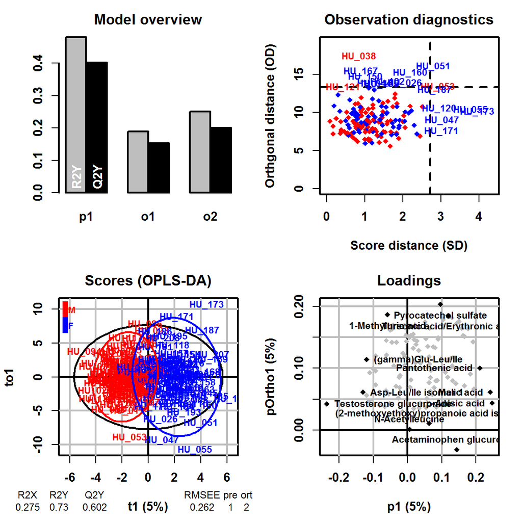

## 4.7 Importing/exporting data from/to the Workflow4metabolomics infrastructure

Galaxy is a web-based environment providing powerful graphical user interface and workflow management functionalities for omics data analysis (Goecks et al. (2010); Boekel et al. (2015)). Wrapping an R code into a Galaxy module is quite straight-forward: examples can be found on the [toolshed](https://toolshed.g2.bx.psu.edu) central repository and in the [RGalaxy](https://www.bioconductor.org/packages/release/bioc/html/RGalaxy.html) bioconductor package.

[Workflow4metabolomics](http://workflow4metabolomics.org) (W4M) is the online infrastructure for computational metabolomics based on the Galaxy environment (Giacomoni et al. 2015). W4M enables to build, run, save and share workflows efficiently. In addition, workflows and input/output data (called **histories**) can be [referenced](https://galaxy.workflow4metabolomics.org/history/list_published), thus enabling fully reproducible research. More than 30 modules are currently available for LC-MS, GC-MS and NMR data preprocessing, statistical analysis, and annotation, including wrappers of `xcms`, `CAMERA`, `metaMS`, `ropls`, and `biosigner`, and is open to [new contributions](http://workflow4metabolomics.org/node/49).

In order to facilitate data import from/to W4M, the `fromW4M` function (respectively the `toW4M` method) enables import from (respectively export to) the **W4M 3 tabular file format** (**dataMatrix.tsv**, **sampleMetadata.tsv**, **variableMetadata.tsv**) into (respectively from) an `ExpressionSet` object, as shown in the following example which uses the 3 .tsv files stored in the **extdata** repository of the package to create a *sacSet* ExpressionSet object:

```r
sacSet <- fromW4M(file.path(path.package("ropls"), "extdata"))
sacSet
```

```
## ExpressionSet (storageMode: lockedEnvironment)
## assayData: 109 features, 183 samples
##   element names: exprs
## protocolData: none
## phenoData
##   sampleNames: HU_011 HU_014 ... HU_209 (183 total)
##   varLabels: age bmi gender
##   varMetadata: labelDescription
## featureData
##   featureNames: X.2.methoxyethoxy.propanoic.acid.isomer
##     X.gamma.Glu.Leu.Ile ... Xanthosine (109 total)
##   fvarLabels: msiLevel hmdb chemicalClass
##   fvarMetadata: labelDescription
## experimentData: use 'experimentData(object)'
## Annotation:
```

The generated *sacSet* `ExpressionSet` object can be used with the `opls` method as described in the previous section.

Conversely, an `ExpressionSet` (with filled **assayData**, **phenoData** and **featureData** slots) can be exported to the 3 table W4M format:

```r
toW4M(sacSet, paste0(getwd(), "/out_"))
```

Before moving to the next session whith another example dataset, we detach *sacurine* from the search path:

```r
detach(sacurine)
```

# 5 Other datasets

In addition to the *sacurine* dataset presented above, the package contains the following datasets to illustrate the functionalities of PCA, PLS and OPLS (see the examples in the documentation of the opls function):

- **aminoacids** Amino-Acids Dataset. Quantitative structure property relationship (QSPR) (Wold, Sjostrom, and Eriksson 2001).
- **cellulose** NIR-Viscosity example data set to illustrate multivariate calibration using PLS, spectral filtering and OPLS (Multivariate calibration using spectral data. Simca tutorial. Umetrics, Sweden).
- **cornell** Octane of various blends of gasoline: Twelve mixture component proportions of the blend are analysed (Tenenhaus 1998).
- **foods** Food consumption patterns accross European countries (FOODS). The relative consumption of 20 food items was compiled for 16 countries. The values range between 0 and 100 percent and a high value corresponds to a high consumption. The dataset contains 3 missing data (Eriksson et al. 2001).
- **linnerud** Three physiological and three exercise variables are measured on twenty middle-aged men in a fitness club (Tenenhaus 1998).
- **lowarp** A multi response optimization data set (LOWARP) (Eriksson et al. 2001).
- **mark** Marks obtained by french students in mathematics, physics, french and english. Toy example to illustrate the potentialities of PCA (Baccini 2010).